# Psychometrics and SEM Data Retake Assignment II 2024-2025

Jia Song s3952932

2024-11-26

# Introduction

The study focuses on investigating changes in life satisfaction among young adults across two time points, 1987 and 1991. Life satisfaction was measured with three indicators at each time point: “In most respects my life is ideal,” “My living conditions are excellent,” and “Overall I am satisfied with my life.”. Additionally, we performed a longitudinal confirmatory factor analysis(CFA) to assess the relationship between the life satisfaction factors for both years and determine whether life satisfaction of young adults changed overtime.

The empirical question is whether life satisfaction has improved or deteriorated during this period. The results of these analyses will allow us to draw conclusions about general trends in life satisfaction among the survey participants.

# Method

## Dataset

**Variables: Life satisfaction indicators for both years include the following:**

| 1987 Indicators | 1991 Indicators | Statements |
| --- | --- | --- |
| S341 | SS281 | In most respects my life is ideal |
| S342 | SS282 | My life conditions are excellent |
| S343 | SS283 | Overall I am satisfied with my life |

## Statistical Analysis

### Missingness

The data included missing values for indicators which followed a completely random missing (MCAR) mechanism. To address this problem, these missing values were removed by using a listwise approach. This led to a final sample of 1,245 participants for analysis. All indicator Likert scale responses are assumed to be numerical. After data preparation, descriptive statistics (mean, standard deviation, covariance) were computed for all indicators.

### Identification

It is crucial to examine whether the model is identifiable or not, because the identifiability refers to whether the data provide enough information to uniquely estimate the model parameters in the background of SEM. A model is identifiable if it has positive degrees of freedom, meaning that there are more known data points (variances and covariances) than there are parameters to be estimated.

Based on the formula in the slide,
$$df =
1/2(p(p+1)) - q$$
. We get the total estimated parameters are:
$$q = 6 \text{(factor loadings)} + 6
\text{(observed variances)} + 1 \text{(latent factor covariance)} + 3
\text{(error covariances)} = 16$$
And the degrees of freedom are:
$$df = 1/2(6(6+1) - 15 = 21 - 16 = 5$$
.

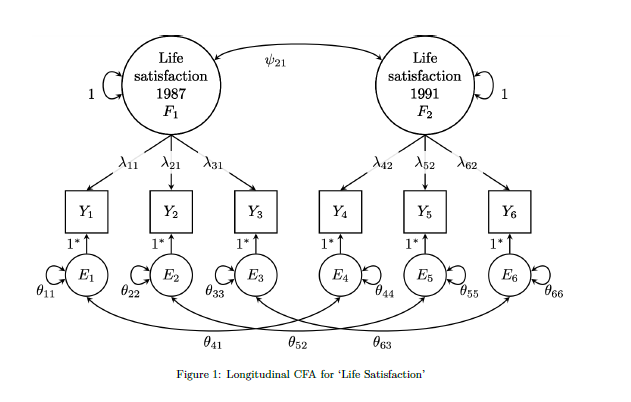

The degrees of freedom are indeed positive, indicating the model is over-identified with more known than unknown information. And this allows us to proceed with testing for measurement invariance.

### Longitudinal Factor Analysis

- **Configural Invariance:** To observe whether the same factor structure is consistent at different time points between 1987 and 1991 without restricting any parameters.
- **Metric Invariance:** To test the equality of factor loadings across time points, testing whether the relationships between the observed items and the latent construct Life Satisfaction are consistent between 1987 and 1991 by constraining the **factor loadings** to be equal across time.
- **Scalar Invariance:** To test the equality of item intercepts across time points, ensuring that the means of the indicators are comparable over time.

# Results

## Descriptive Statistics

The following 2 tables illustrate the mean, standard deviation and covariance for each indicator. These descriptives provide an initial insight into the distribution of Life Satisfaction responses and the relationships between the indicators over time, which will be further explored in the confirmatory factor analysis.

The table of descriptive statistics

|  | Means | Standard_deviations |
| --- | --- | --- |
| S341 | 5.072289 | 1.411794 |
| S342 | 5.502008 | 1.307671 |
| S343 | 5.874699 | 1.248296 |
| SS281 | 5.225703 | 1.256359 |
| SS282 | 5.606426 | 1.204610 |
| SS283 | 5.853815 | 1.185861 |

Covariance Matrix

|  | S341 | S342 | S343 | SS281 | SS282 | SS283 |
| --- | --- | --- | --- | --- | --- | --- |
| S341 | 1.9931624 | 1.1461570 | 1.0372002 | 0.5785263 | 0.5019467 | 0.4382288 |
| S342 | 1.1461570 | 1.7100040 | 0.8981618 | 0.4058969 | 0.5353569 | 0.3877536 |
| S343 | 1.0372002 | 0.8981618 | 1.5582420 | 0.3466315 | 0.3919634 | 0.4430829 |
| SS281 | 0.5785263 | 0.4058969 | 0.3466315 | 1.5784385 | 0.9916354 | 0.9767507 |
| SS282 | 0.5019467 | 0.5353569 | 0.3919634 | 0.9916354 | 1.4510841 | 0.8515832 |
| SS283 | 0.4382288 | 0.3877536 | 0.4430829 | 0.9767507 | 0.8515832 | 1.4062656 |

On the other hand, the standard deviations in 1987 ranged from 1.25 to 1.41, while in 1991, they were slightly lower at 1.18 to 1.26, indicating the satisfactions were generally clustered around the mean. Alongside of this, the covariance matrix showed a positive association among satisfaction indicators in both 1987 and 1991.

Based on these observations, we performed general models to further assess relationships and trends in the data. And the mean structure is :

$$\begin{aligned}
\mathbb{E}(Y_1) &= \lambda_{11} \kappa_1 + \nu_1, \\
\mathbb{E}(Y_2) &= \lambda_{21} \kappa_1 + \nu_2, \\
\mathbb{E}(Y_3) &= \lambda_{31} \kappa_1 + \nu_3, \\
\mathbb{E}(Y_4) &= \lambda_{42} \kappa_2 + \nu_4, \\
\mathbb{E}(Y_5) &= \lambda_{52} \kappa_2 + \nu_5, \\
\mathbb{E}(Y_6) &= \lambda_{62} \kappa_2 + \nu_6.
\end{aligned}$$
Where:

- $\nu_i$: The vector of intercepts for the observed indicators,
- ( $\Lambda_{ij}$ ):Factor loading of $Y_i$ on latent factor $F_j$,
- $\kappa_j$: The Mean of the latent factor $F_j$

The estimated factor loadings

| Loadings | values | standardised_values | R_square |
| --- | --- | --- | --- |
| S341 | 1.163 | 0.821 | 0.675 |
| S342 | 0.983 | 0.755 | 0.571 |
| S343 | 0.899 | 0.720 | 0.519 |
| SS281 | 1.060 | 0.844 | 0.712 |
| SS282 | 0.934 | 0.776 | 0.602 |
| SS283 | 0.918 | 0.774 | 0.599 |

The estimated factor covariance

| Covariances | values |
| --- | --- |
| psi21 | 0.414 |
| P-value | 0.000 |
| standardised values | 0.414 |

According to the factor loading table, F1(life satisfaction in 1987) explains 67.5%, 57.1%, and 51.9% of the variance in S341, S342, and S343, respectively, with standardized loadings of 0.821, 0.755, and 0.720, respectively. Similarly, F2(life satisfaction in 1991) explained 71.2%, 60.2%, and 59.9% of the variance in SS281, SS282, and SS283, with standardized loadings of 0.844, 0.776, and 0.774, respectively.

The relatively high R-squared values indicate that the latent factors explain a significant proportion of the variance in their corresponding observed variables. This suggests that the observed variables are strongly influenced by the latent constructs, showing that the observed variables are good indicators.

Based on the outputs in the table of the estimated factor covariance, the covariance between F1 and F2 is 0.414, with a P-value < .001, this shows a significant positive relationship between 2 latent variables.

## Configural Invariance

Configural Invariance Model

| Measure | Value |
| --- | --- |
| Chi-squared | 9.146 |
| df | 5.000 |
| p-value | 0.103 |
| RMSEA | 0.026 |
| CFI | 0.999 |

According to the table of the configural invaraince model, the chi-squared test shows an excellent fit since the p-value is greater than 0.05. Additionally, the RMSEA is around 0.026 which is below the threshold of 0.05, also indicating a good fit.The CFI value is 0.999,which is greater than 0.95, demonstrating an excellent comparative fit. Overall, these metrics suggest that the configural invariance model fit the data well, hence we can set more constraints to observe the difference.

## Weak Factorial Invariance

We then add the constraint that the factor loadings were equal across time points, and we want to test whether the relationship between the latent factors and the observed variables remain consistent over time.

Weak Invariance Model

| Measure | Value |
| --- | --- |
| Chi-squared | 13.762 |
| df | 7.000 |
| p-value | 0.056 |
| RMSEA | 0.028 |
| CFI | 0.998 |

The p-value is greater than 0.05, also indicating the weak factorial invariance model fit well the data and also supported by the RMSEA and CFI values. Comparing with previous model, we observe that the metric invariance model has a chi-square of 13.762 with 7 degrees of freedom, the chi-square has slightly increased because of the additional constraints. Additionally, while the CFI has slightly decreased to 0.998 and the RMSEA reached at 0.028.

To test whether the equality constraints on the factor loadings lead to a significant decrease in model fit. We perform an analysis of variance (ANOVA) test.

$$H_0: \text{The weak factorial model
fits the data as well as the configural model.}$$
$$H_A: \text{The weak factorial model does not fit
the data as well as the configural model.}$$

The ANOVA table between the Configural model and Weak factorial model

| Model | AIC | BIC | X.Chisq | Chisq.diff | RMSEA | P.Value |
| --- | --- | --- | --- | --- | --- | --- |
| Configural | 21755 | 21868 | 9.1461 |  |  |  |
| Weak | 21756 | 21858 | 13.7625 | 4.6163 | 0.0324 | 0.0994 |

According to the ANOVA table, since the p-value for the Chi-squared difference test is greater than 0.05 ($p = 0.099$), we fail to reject the $H_0$. This suggests that the model fit has not significantly worsened compared to the configural model, and the weak factorial invariance model remains a good fit. The minimal changes in AIC and BIC values further support this conclusion. These results indicate that constraining the factor loadings to be equal across time does not significantly deteriorate the model fit. Therefore, the assumption of metric invariance holds, suggesting that the relationship between the latent factors and observed variables is consistent over time.

## Strong Factorial Invariance

Strong Factorial Invariance Model

| Measure | Value |
| --- | --- |
| Chi-squared | 29.918 |
| df | 9.000 |
| p-value | 0.000 |
| RMSEA | 0.043 |
| CFI | 0.993 |

The ANOVA table between the weak and strong factorial models

| Model | AIC | BIC | Chisq | Chisq.diff | RMSEA | P.Value |
| --- | --- | --- | --- | --- | --- | --- |
| Weak | 21756 | 21858 | 13.762 |  | 0.0754 |  |
| Strong | 21768 | 21860 | 29.918 | 16.156 | 0.0754 | 0 |

However, since the p-value of the anova test is smaller than 0.05, we reject the null hypothesis. The equality constraint on the intercept worsens the model significantly.Therefore, strong factorial invariance does not hold. Furthermore, this means that the observed items (S341, S342, S342, etc.) do not have the same baseline (intercept) between time points (1987 and 1991). This results that my final model is the weak factorial model.

## Final Model

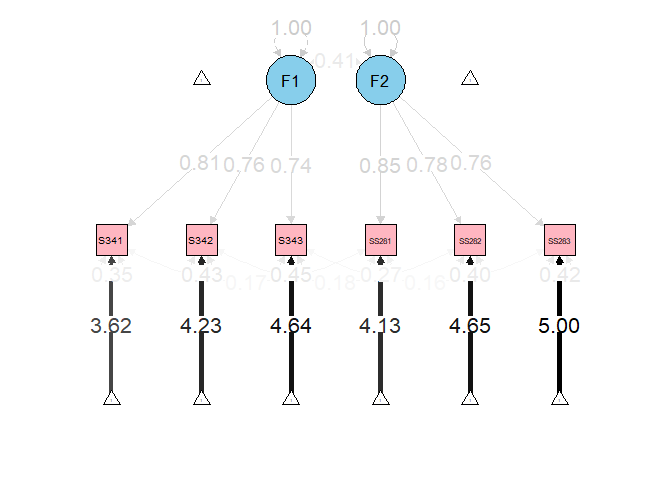

In additionally, we observed the path diagram depicted the relationship between 2 latent factors and their observed variables shows the almost same estimates with the outputs of the metric model. F1 and F2 are correlated, as indicated by the curved arrow between them, with a correlation coefficient of 0.41.This suggests a moderate positive relationship between life satisfaction in 1987 and 1991.

The standardized values of loadings for observed variables S341, S342, and S343 are 0.81, 0.76, and 0.74, respectively. The 1991 indicators are represented by SS281, SS282, and SS283. These are observed variables that load onto the F2 factor with standardized factor loadings of 0.85, 0.78, and 0.76, respectively. Higher loadings indicate that the observed variables are strongly associated with their corresponding latent factors.

And the residual varainces are represented by the black transparent values such as 0.35,0.43,0.45,0.27,0.40 and 0.42. These values indicate the portion of variance in the observed variable that is not explained by the latent factor. The mean scores are represented by 3.62,4.23,4.64,4.13,4.65 and 5.00.

# Discussion

Since the metric model does not include the constraints of intercepts of the observed variables, this means it allows for differences in intercepts across time. I.e. we cannot compare the means of the life satisfaction between 1987 and 1991 in the metric model, because the baseline levels of life satisfaction indicators in 1987 versus in 1991 are not constrained and they could vary. And if we want to test whether life satisfaction has improved or deteriorated from 1987 to 1991, we would need to establish scalar invariance, where both factor loadings and intercepts are constrained to be equal across time.

In conclusion, although life satisfaction was measured consistently in terms of its relationships with observed variables across 1987 and 1991, due to the lack of scalar invariance, we could not definitively conclude whether ‘Life Satisfaction’ improves or deteriorates from 1987 to 1991.